# lab_3_v3

### Lab 3 Logistic Regression

#### Tingting Zhao & Sian Xiao

```python
import os
import warnings

import matplotlib.pyplot as plt
%matplotlib inline
import numpy as np
import pandas as pd
import seaborn as sns
from numpy import ma
from numpy.linalg import pinv
from scipy.optimize import fmin_bfgs
from scipy.special import expit
from sklearn import metrics as mt
from sklearn.linear_model import LogisticRegression
from sklearn.metrics import accuracy_score
from sklearn.model_selection import ShuffleSplit, train_test_split
from sklearn.preprocessing import MinMaxScaler

warnings.simplefilter('ignore', DeprecationWarning)
warnings.simplefilter('ignore', FutureWarning)
warnings.simplefilter('ignore', RuntimeWarning)
```

## 1. Preparation and Overview

### 1.1 Business Understanding

FIFA is a famous football game, along with FM (football manager) and PES (Pro Evolution Soccer, renamed to eFootball now). Many football players themselves would play FIFA in their spare time, and care about their scores in the game. Due to its accurate scores, even clubs use it to look for high-potential young players.

To describe a football player, we can use a lot of evaluation indicators. Basically, every player (except goalkeepers) has a simple card with six general abilities:

- Defending (DEF) - A player’s all-round defensive abilities, including tackling, heading and positioning.
- Dribbling (DRI) - A player’s dribbling ability.
- Pace (PAC) - The speed of a player.
- Passing (PAS) - A player’s passing ability.
- Physical (PHY) - A player’s overall physical attributes, including their strength.
- Shooting (SHO)- The player’s shooting ability.

Every general ability has more detailed information called attributes. Different players have different attributes, which make them unique.

This dataset contains detailed attributes for every player registered in FIFA 19 (2019 edition). We want to use the attributes to predict the position for a player.

Predicting the position for an existing player makes no sense since we all know who he is, and which position he plays. However, there are two possible applications of our model.

First, many players may change position during their youth or early career, some players even change position in the late period of career. This model based on attributes can help coaches or players themselves to plan their career.

Second, PES has a game mode to create a player by user and add him to the game. We can also develop this here. A created player can have certain initial points and user can allocate these points to different attributes and the game might give a recommended position for the player. Also, the player can be totally randomly created by the game with a rational position.

### 1.2 Define and prepare class variables.

```python
##read data
data=pd.read_csv("data.csv")
data.head()
```

|  | Unnamed: 0 | ID | Name | Age | Photo | Nationality | Flag | Overall | Potential | Club | ... | Composure | Marking | StandingTackle | SlidingTackle | GKDiving | GKHandling | GKKicking | GKPositioning | GKReflexes | Release Clause |
| --- | --- | --- | --- | --- | --- | --- | --- | --- | --- | --- | --- | --- | --- | --- | --- | --- | --- | --- | --- | --- | --- |
| 0 | 0 | 158023 | L. Messi | 31 | https://cdn.sofifa.org/players/4/19/158023.png | Argentina | https://cdn.sofifa.org/flags/52.png | 94 | 94 | FC Barcelona | ... | 96.0 | 33.0 | 28.0 | 26.0 | 6.0 | 11.0 | 15.0 | 14.0 | 8.0 | €226.5M |
| 1 | 1 | 20801 | Cristiano Ronaldo | 33 | https://cdn.sofifa.org/players/4/19/20801.png | Portugal | https://cdn.sofifa.org/flags/38.png | 94 | 94 | Juventus | ... | 95.0 | 28.0 | 31.0 | 23.0 | 7.0 | 11.0 | 15.0 | 14.0 | 11.0 | €127.1M |
| 2 | 2 | 190871 | Neymar Jr | 26 | https://cdn.sofifa.org/players/4/19/190871.png | Brazil | https://cdn.sofifa.org/flags/54.png | 92 | 93 | Paris Saint-Germain | ... | 94.0 | 27.0 | 24.0 | 33.0 | 9.0 | 9.0 | 15.0 | 15.0 | 11.0 | €228.1M |
| 3 | 3 | 193080 | De Gea | 27 | https://cdn.sofifa.org/players/4/19/193080.png | Spain | https://cdn.sofifa.org/flags/45.png | 91 | 93 | Manchester United | ... | 68.0 | 15.0 | 21.0 | 13.0 | 90.0 | 85.0 | 87.0 | 88.0 | 94.0 | €138.6M |
| 4 | 4 | 192985 | K. De Bruyne | 27 | https://cdn.sofifa.org/players/4/19/192985.png | Belgium | https://cdn.sofifa.org/flags/7.png | 91 | 92 | Manchester City | ... | 88.0 | 68.0 | 58.0 | 51.0 | 15.0 | 13.0 | 5.0 | 10.0 | 13.0 | €196.4M |

5 rows × 89 columns

#### 1.2.1 Remove variables that are not needed/useful for the analysis.

```python
print("data.csv includes attributes:")
data.columns
```

```
data.csv includes attributes:
```

```
Index(['Unnamed: 0', 'ID', 'Name', 'Age', 'Photo', 'Nationality', 'Flag',
       'Overall', 'Potential', 'Club', 'Club Logo', 'Value', 'Wage', 'Special',
       'Preferred Foot', 'International Reputation', 'Weak Foot',
       'Skill Moves', 'Work Rate', 'Body Type', 'Real Face', 'Position',
       'Jersey Number', 'Joined', 'Loaned From', 'Contract Valid Until',
       'Height', 'Weight', 'LS', 'ST', 'RS', 'LW', 'LF', 'CF', 'RF', 'RW',
       'LAM', 'CAM', 'RAM', 'LM', 'LCM', 'CM', 'RCM', 'RM', 'LWB', 'LDM',
       'CDM', 'RDM', 'RWB', 'LB', 'LCB', 'CB', 'RCB', 'RB', 'Crossing',
       'Finishing', 'HeadingAccuracy', 'ShortPassing', 'Volleys', 'Dribbling',
       'Curve', 'FKAccuracy', 'LongPassing', 'BallControl', 'Acceleration',
       'SprintSpeed', 'Agility', 'Reactions', 'Balance', 'ShotPower',
       'Jumping', 'Stamina', 'Strength', 'LongShots', 'Aggression',
       'Interceptions', 'Positioning', 'Vision', 'Penalties', 'Composure',
       'Marking', 'StandingTackle', 'SlidingTackle', 'GKDiving', 'GKHandling',
       'GKKicking', 'GKPositioning', 'GKReflexes', 'Release Clause'],
      dtype='object')
```

**Data attributes can be categorized into personal information, contract information, game information, position scores, and attributes describing football players' abilities that can be categorized into Physical, Mental, Skills.**

- Personal information: 'Unnamed: 0', 'ID', 'Name', 'Age', 'Photo', 'Nationality', 'Flag', 'Club', 'Club Logo', 'Value', 'Wage', 'Special', 'Preferred Foot', 'International Reputation', 'Weak Foot'
- Contract information: 'Jersey Number', 'Joined', 'Loaned From', 'Contract Valid Until', 'Release Clause'
- Game information: 'Overall', 'Potential', 'Skill Moves', 'Body Type', 'Real Face','Work Rate'
- Position scores: 'LS', 'ST', 'RS', 'LW', 'LF', 'CF', 'RF', 'RW', 'LAM', 'CAM', 'RAM', 'LM', 'LCM', 'CM', 'RCM', 'RM', 'LWB', 'LDM', 'CDM', 'RDM', 'RWB', 'LB', 'LCB', 'CB', 'RCB', 'RB'

**Attributes describing football players' abilities:**

- Physical: 'Acceleration','Stamina', 'Strength','SprintSpeed','Reactions','Jumping', 'Agility', 'Balance'
- Mental: 'Aggression','Composure','Interceptions','Marking','Positioning','Vision'
- Skills: 'Crossing', 'Finishing','HeadingAccuracy', 'ShortPassing', 'Volleys', 'Dribbling', 'Curve', 'FKAccuracy', 'LongPassing', 'BallControl', 'ShotPower', 'LongShots', 'Penalties', 'StandingTackle', 'SlidingTackle', 'GKDiving', 'GKHandling','GKKicking', 'GKPositioning', 'GKReflexes'

**Personal information, contract information and game information are not related to the purpose of predicting players' postions, position scores was inclued in 'Position' attribute. So these attributes will be dropped off.**

**However, work rate of gameinfo will be kept as the category data in the data set. Among all the category attribute, we think work rate is mostly related to the purpose of predicting players' postions since players of different positions have different responsiblities for attack and defense.**

The Work Rate is defined for Attacking (Attacking Work Rate - Abbreviated as AWR) and Defensive (Defensive Work Rate - Abbreviated as DWR) and rated between low, medium and high, which defines how a player puts effort to participates in attacks and defenses even when they are out of position.

**Work rate attribute will be split into two attribute AWD and DWR, and the rate low, medium, high will be represented as 1,2,3.**

```python
infoLists = ['GKHandling', 'GKKicking',
             'GKPositioning', 'GKReflexes', 'StandingTackle']
personalInfo = ['Unnamed: 0', 'ID', 'Name', 'Age', 'Photo', 'Nationality', 'Flag',  'Club',
                'Club Logo', 'Value', 'Wage', 'Special', 'Preferred Foot', 'International Reputation', 'Weak Foot']
contractInfo = ['Jersey Number', 'Joined', 'Loaned From',
                'Contract Valid Until', 'Release Clause']
gameInfo = ['Overall', 'Potential', 'Skill Moves', 'Body Type',
            'Real Face']  # take "Work rate" out of this list
positionInfo = ['LS', 'ST', 'RS', 'LW', 'LF', 'CF', 'RF', 'RW',
                'LAM', 'CAM', 'RAM', 'LM', 'LCM', 'CM', 'RCM', 'RM', 'LWB', 'LDM',
                'CDM', 'RDM', 'RWB', 'LB', 'LCB', 'CB', 'RCB', 'RB']

infoLists = [personalInfo, contractInfo, gameInfo, positionInfo]
for infoList in infoLists:
    for info in infoList:
        del data[info]
```

#### 1.2.2 Missing data and duplicates.

```python
print(data.shape)
print(f"There are {data.isnull().any(axis=1).sum()} data missing")
print(f"There are {data.duplicated().sum()} duplicated data")
# drop missing data
data = data.dropna(how='any')
data = data.drop_duplicates()
print(data.shape)
```

```
(18207, 38)
There are 60 data missing
There are 48 duplicated data
(18146, 38)
```

**The missing data only makes up a small part of the whole data set, drop off them won't influence the prediction performance.**

#### 1.2.3 Use proper variable representations.

```python
def weight_to_int(df_weight):
    value = int(df_weight[:-3])
    return value


def height_to_int(df_height):
    feet, dlm = map(int, df_height.split("'"))
    return round(feet * 12 + dlm * 2.54, 0)


data['Weight_int'] = data['Weight'].apply(weight_to_int)
data['Height_int'] = data['Height'].apply(height_to_int)
data = data.drop('Height', axis=1)
data = data.drop('Weight', axis=1)


# Attacking Work Rate - Abbreviated as AWR
def work_rate_AWR(df_work_rate):
    dic = {"High": 3, "Medium": 2, "Low": 1}
    AWR = dic[df_work_rate.split("/")[0]]
    return AWR


#  Defensive Work Rate - Abbreviated as DWR
def work_rate_DWR(df_work_rate):
    dic = {"High": 3, "Medium": 2, "Low": 1}
    DWR = dic[df_work_rate.split("/ ")[1]]
    return DWR


data['AWR'] = data["Work Rate"].apply(work_rate_AWR)
data['DWR'] = data["Work Rate"].apply(work_rate_DWR)
data = data.drop("Work Rate", axis=1)


# group positions into four categories
# cite from https://www.analyticsvidhya.com/blog/2021/07/performing-multi-class-classification-on-fifa-dataset-using-keras/
forward_player = ["ST", "LW", "RW", "LF", "RF", "RS", "LS", "CF"]
midfielder_player = ["CM", "RCM", "LCM", "CDM",
                     "RDM", "LDM", "CAM", "LAM", "RAM", "RM", "LM"]
defender_player = ["CB", "RCB", "LCB", "LWB", "RWB", "LB", "RB"]
data.loc[data["Position"] == "GK", "Position"] = 0
data.loc[data["Position"].isin(defender_player), "Position"] = 1
data.loc[data["Position"].isin(midfielder_player), "Position"] = 2
data.loc[data["Position"].isin(forward_player), "Position"] = 3
data.info()
data.head()
```

```
<class 'pandas.core.frame.DataFrame'>
Int64Index: 18146 entries, 0 to 18206
Data columns (total 39 columns):
 #   Column           Non-Null Count  Dtype
---  ------           --------------  -----
 0   Position         18146 non-null  object
 1   Crossing         18146 non-null  float64
 2   Finishing        18146 non-null  float64
 3   HeadingAccuracy  18146 non-null  float64
 4   ShortPassing     18146 non-null  float64
 5   Volleys          18146 non-null  float64
 6   Dribbling        18146 non-null  float64
 7   Curve            18146 non-null  float64
 8   FKAccuracy       18146 non-null  float64
 9   LongPassing      18146 non-null  float64
```

[output cut: 31 more lines]

|  | Position | Crossing | Finishing | HeadingAccuracy | ShortPassing | Volleys | Dribbling | Curve | FKAccuracy | LongPassing | ... | SlidingTackle | GKDiving | GKHandling | GKKicking | GKPositioning | GKReflexes | Weight_int | Height_int | AWR | DWR |
| --- | --- | --- | --- | --- | --- | --- | --- | --- | --- | --- | --- | --- | --- | --- | --- | --- | --- | --- | --- | --- | --- |
| 0 | 3 | 84.0 | 95.0 | 70.0 | 90.0 | 86.0 | 97.0 | 93.0 | 94.0 | 87.0 | ... | 26.0 | 6.0 | 11.0 | 15.0 | 14.0 | 8.0 | 159 | 78.0 | 2 | 2 |
| 1 | 3 | 84.0 | 94.0 | 89.0 | 81.0 | 87.0 | 88.0 | 81.0 | 76.0 | 77.0 | ... | 23.0 | 7.0 | 11.0 | 15.0 | 14.0 | 11.0 | 183 | 77.0 | 3 | 1 |
| 2 | 3 | 79.0 | 87.0 | 62.0 | 84.0 | 84.0 | 96.0 | 88.0 | 87.0 | 78.0 | ... | 33.0 | 9.0 | 9.0 | 15.0 | 15.0 | 11.0 | 150 | 83.0 | 3 | 2 |
| 3 | 0 | 17.0 | 13.0 | 21.0 | 50.0 | 13.0 | 18.0 | 21.0 | 19.0 | 51.0 | ... | 13.0 | 90.0 | 85.0 | 87.0 | 88.0 | 94.0 | 168 | 82.0 | 2 | 2 |
| 4 | 2 | 93.0 | 82.0 | 55.0 | 92.0 | 82.0 | 86.0 | 85.0 | 83.0 | 91.0 | ... | 51.0 | 15.0 | 13.0 | 5.0 | 10.0 | 13.0 | 154 | 88.0 | 3 | 3 |

5 rows × 39 columns

#### 1.2.4 delete highly correlated data

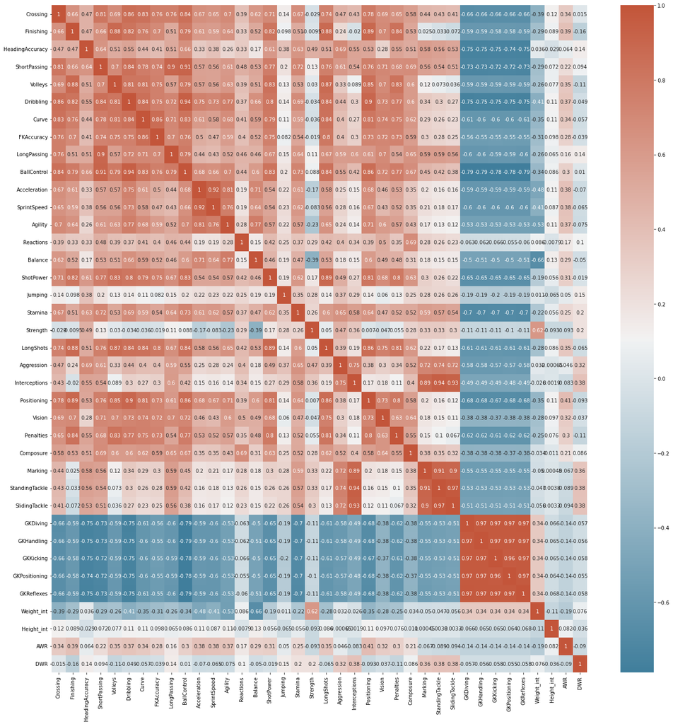

```python
cmap = sns.diverging_palette(230, 20, as_cmap=True)
f, ax = plt.subplots(figsize=(20,20))
sns.heatmap(data.corr(), annot=True, cmap=cmap)
f.tight_layout()
```

**'GKDiving','GKHandling','GKKicking', 'GKPositioning' and 'GKReflexes' have more than 95% correlation, same thing happends to 'StandingTackle', and 'SlidingTackle'. So, only 'GKDiving'(any of the five correlated is okay) and 'StandingTackle'(any of the two correlated is okay) will be kept in the data set.**

```python
infoLists = [ 'GKHandling','GKKicking', 'GKPositioning', 'GKReflexes','StandingTackle']
for info in infoLists:
    del data[info]
```

#### 1.2.5 Plot distribution of attributes and targets.

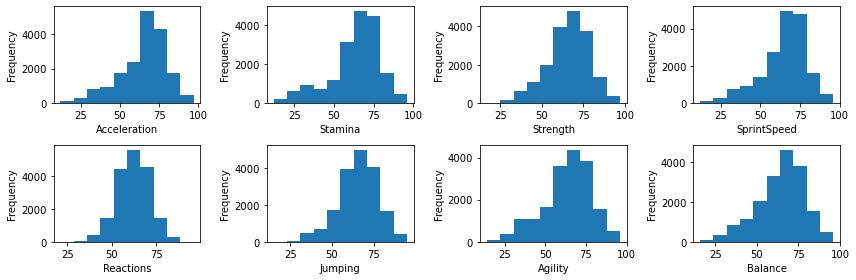

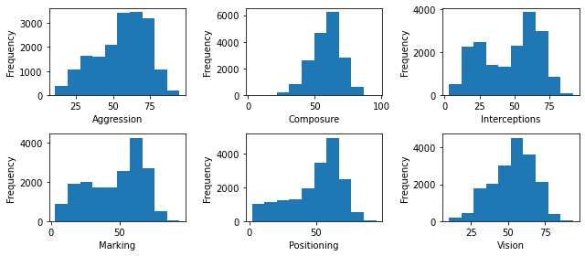

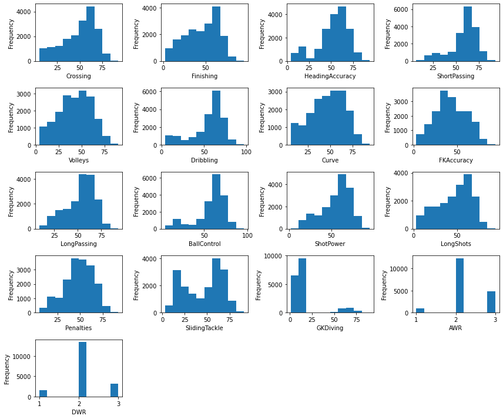

```python
Physical = ['Acceleration', 'Stamina', 'Strength',
            'SprintSpeed', 'Reactions', 'Jumping', 'Agility', 'Balance']
Mental = ['Aggression', 'Composure', 'Interceptions',
          'Marking', 'Positioning', 'Vision']
Skills = ['Crossing', 'Finishing', 'HeadingAccuracy', 'ShortPassing', 'Volleys', 'Dribbling',
          'Curve', 'FKAccuracy', 'LongPassing', 'BallControl',  'ShotPower', 'LongShots',  'Penalties', 'SlidingTackle',  'GKDiving', "AWR", "DWR"]  # 'StandingTackle','GKHandling','GKKicking', 'GKPositioning', 'GKReflexes']
f, ax = plt.subplots(figsize=(12, 4))
for i in range(1, 9):
    plt.subplot(2, 4, i)
    data[Physical[i-1]].plot.hist()
    plt.xlabel(Physical[i-1])
    plt.tight_layout()

f, ax = plt.subplots(figsize=(9, 4))
for i in range(1, 7):
    plt.subplot(2, 3, i)
    data[Mental[i-1]].plot.hist()
    plt.xlabel(Mental[i-1])
    plt.tight_layout()

f, ax = plt.subplots(figsize=(12, 10))
for i in range(1, 18):
    plt.subplot(5, 4, i)
    data[Skills[i-1]].plot.hist()
    plt.xlabel(Skills[i-1])
    plt.tight_layout()
```

**The plots show that not all the attributes have normal distribution. Since minmax scaler preserves the underlying distribution, so when we preprocess the feature before fitting into models we should use minmax scaler**

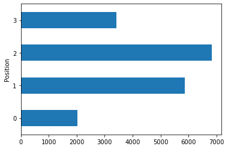

```python
#target distribution
data.groupby(by=["Position"]).Position.count().plot(kind='barh')
```

#### 1.2.6 Scale the data.

```python
X = data.drop("Position", axis = 1).to_numpy()
y = data["Position"].values
print("X shape:",X.shape,"y shape:",y.shape)
print("Before scaling...")
print(X)

X_scaled=MinMaxScaler().fit_transform(X)
print("After scaling...")
print(X_scaled)
```

```
X shape: (18146, 33) y shape: (18146,)
Before scaling...
[[84. 95. 70. ... 78.  2.  2.]
 [84. 94. 89. ... 77.  3.  1.]
 [79. 87. 62. ... 83.  3.  2.]
 ...
 [25. 40. 46. ... 80.  2.  2.]
 [44. 50. 39. ... 85.  2.  2.]
 [41. 34. 46. ... 85.  2.  2.]]
After scaling...
[[0.89772727 1.         0.73333333 ... 0.46875    0.5        0.5       ]
 [0.89772727 0.98924731 0.94444444 ... 0.4375     1.         0.        ]
 [0.84090909 0.91397849 0.64444444 ... 0.625      1.         0.5       ]
 ...
 [0.22727273 0.40860215 0.46666667 ... 0.53125    0.5        0.5       ]
 [0.44318182 0.51612903 0.38888889 ... 0.6875     0.5        0.5       ]
 [0.40909091 0.34408602 0.46666667 ... 0.6875     0.5        0.5       ]]
```

### 1.3 Divide data into training and testing data using an 80% training and 20% testing split.

Use the cross validation modules that are part of scikit-learn. Argue "for" or "against" splitting your data using an 80/20 split. That is, why is the 80/20 split appropriate (or not) for your dataset?

```
(14516, 33) (3630, 33) (14516,) (3630,)
```

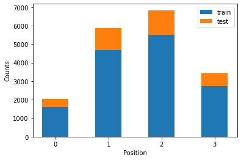

```python
#split the data into train, validation, test
X_train, X_test, y_train, y_test = train_test_split(X_scaled, y, test_size=0.2, random_state=42)
print(X_train.shape, X_test.shape, y_train.shape,y_test.shape)

y_stat = [np.where(y==0)[0].shape[0], np.where(y==1)[0].shape[0], np.where(y==2)[0].shape[0], np.where(y==3)[0].shape[0]]
y_train_stat =[np.where(y_train==0)[0].shape[0], np.where(y_train==1)[0].shape[0], np.where(y_train==2)[0].shape[0], np.where(y_train==3)[0].shape[0]]
y_test_stat =[np.where(y_test==0)[0].shape[0], np.where(y_test==1)[0].shape[0], np.where(y_test==2)[0].shape[0], np.where(y_test==3)[0].shape[0]]


width = 0.5       # the width of the bars: can also be len(x) sequence
fig, ax = plt.subplots()

ax.bar([0,1,2,3], y_train_stat, width, label='train')
ax.bar([0,1,2,3], y_test_stat, width, bottom=y_train_stat,label='test')

ax.set_ylabel('Counts')
ax.set_xlabel('Position')
ax.set_xticks(range(4))
ax.legend()

plt.show()
```

**Since there are more than 18000 data points in the dataset, so 20% of dataset as test set would be give a stable evaluation of the model. As we can see, both train set and test set have a good sample of each class.**

## 2. Modeling (5 points total)

### 2.1 One-versus-all logistic regression classifier

```python
class MultiClassLogisticRegression:
    def __init__(self, eta=1, iterations=20,  C=0.0001, solver="bfgs", regulation="L2",l1_ratio=0.1):
        if regulation not in "L1, L2, elasticnet, None":
            print("regulation not recognized. Defaulting to L2.")
            regulation="L2"
        if solver not in "stochastic-gradient-descent, steepest-descent, newton-cg, bfgs":
            print("solver not recognized. Defaulting to bfgs.")
            solver="bfgs"
        self.eta = eta
        self.iters = iterations
        self.C = C
        self.solver = solver
        self.regu = regulation
        self.l1_ratio=l1_ratio
        self.classifiers_ = []
        # internally we will store the weights as self.w_ to keep with sklearn conventions
        # convenience, private:

    @staticmethod
    def _add_bias(X):
        return np.hstack((np.ones((X.shape[0],1)),X)) # add bias term

    @staticmethod
    def _sigmoid(theta):
        # increase stability, redefine sigmoid operation
        return expit(theta) #1/(1+np.exp(-theta))

    @staticmethod
    def _L1(gradient,w,C):
        for i in range(1,w.shape[0]):
            if w[i] !=0:
                gradient[i] += -1 * C * (w[i])/np.abs(w[i])
            else:
                gradient[i] += 0
        return gradient

    @staticmethod
    def _L2(gradient,w,C):
        gradient[1:] += -2 * w[1:] * C
        return gradient

    @staticmethod
    def _elasticnet(gradient,w,C,l1_ratio):
        for i in range(1,w.shape[0]):
            if w[i] !=0:
                gradient[i] += -2 * w[i] * C * (1-l1_ratio) -1 * C * (w[i])/np.abs(w[i]) *l1_ratio
            else:
                gradient[i] += -2 * w[i] * C * (1-l1_ratio)
        return gradient



    @staticmethod
    def objective_function(w,X,y,C,l1_ratio,regulation):
        g = expit(X @ w)
        # invert this because scipy minimizes, but we derived all formulas for maximzing
        return -np.sum(ma.log(g[y==1]))-np.sum(ma.log(1-g[y==0])) + C*sum(w**2)
        #-np.sum(y*np.log(g)+(1-y)*np.log(1-g))

    @staticmethod
    def objective_gradient(w,X,y,C,l1_ratio,regulation):
        g = expit(X @ w)
        ydiff = y-g # get y difference
        gradient = np.mean(X * ydiff[:,np.newaxis], axis=0)
        gradient = gradient.reshape(w.shape)
        if regulation == "L2":
            gradient[1:] += -2 * w[1:] * C
        elif regulation == "L1":
            gradient[1:] += -1 * C
        elif regulation == "elasticnet":
            gradient[1:] += -2 * w[1:] * C * (1-l1_ratio) -1 * C * l1_ratio
        elif regulation == None:
            gradient=gradient
        return -gradient

    @staticmethod
    def options():
        print("regulation: L1, L2, elasticnet, None")
        print("solver: stochastic-gradient-descent, steepest-descent, newton-cg, bfgs")
        print("C: regularization strength; must be a positive float. Larger values specify stronger regularization.")
        print("iterations: number of iterations taken for the solvers")
        print("eta: learning rate")
        print("l1_ratio:The Elastic-Net mixing parameter, with 0 <= l1_ratio <= 1. Only used if regulation='elasticnet'")
        return "----"

    def _get_gradient_newton(self,X,y):
        g = self._predict_proba(X,add_bias=False).ravel() # get sigmoid value for all classes
        ydiff = y-g # get y difference
        gradient = np.sum(X * ydiff[:,np.newaxis], axis=0) # make ydiff a column vector and multiply through
        gradient = gradient.reshape(self.w_.shape)
        if self.regu == "L2":
            hessian = X.T @ np.diag(g*(1-g)) @ X - 2 * self.C # calculate the hessian
            gradient=self._L2(gradient,self.w_,self.C)
        elif self.regu == "L1":
            hessian = X.T @ np.diag(g*(1-g)) @ X  # calculate the hessian
            gradient=self._L1(gradient,self.w_,self.C)
        elif self.regu == "elasticnet":
            hessian = X.T @ np.diag(g*(1-g)) @ X - 2 * self.C * self.l1_ratio # calculate the hessian
            gradient=self._elasticnet(gradient,self.w_,self.C,self.l1_ratio)
        elif self.regu == None:
            gradient=gradient
        return pinv(hessian) @ gradient

    def _get_gradient_steepest(self,X,y):
        ydiff = y-self._predict_proba(X,add_bias=False).ravel() # get y difference
        gradient = np.mean(X * ydiff[:,np.newaxis], axis=0) # make ydiff a column vector and multiply through
        gradient = gradient.reshape(self.w_.shape)
        if self.regu == "L2":
            gradient=self._L2(gradient,self.w_,self.C)
        elif self.regu == "L1":
            gradient=self._L1(gradient,self.w_,self.C)
        elif self.regu == "elasticnet":
            gradient=self._elasticnet(gradient,self.w_,self.C,self.l1_ratio)
        elif self.regu == None:
            gradient=gradient
        return gradient

    def _get_gradient_stochastic(self,X,y):
        idx = int(np.random.rand()*len(y)) # grab random instance
        ydiff = y[idx]-self._predict_proba(X[idx],add_bias=False) # get y difference (now scalar)
        gradient = X[idx] * ydiff[:,np.newaxis] # make ydiff a column vector and multiply through
        gradient = gradient.reshape(self.w_.shape)
        if self.regu == "L2":
            gradient=self._L2(gradient,self.w_,self.C)
        elif self.regu == "L1":
            gradient=self._L1(gradient,self.w_,self.C)
        elif self.regu == "elasticnet":
            gradient=self._elasticnet(gradient,self.w_,self.C,self.l1_ratio)
        elif self.regu == None:
            gradient=gradient
        return gradient

    # choose the optimization method
    def _get_gradient(self,X,y):
        if self.solver=="stochastic-gradient-descent":
            return self._get_gradient_stochastic(X,y)
        elif self.solver=="steepest-descent":
            return self._get_gradient_steepest(X,y)
        elif self.solver == "newton-cg":
            return self._get_gradient_newton(X,y)

    # public for binary classification:
    def _predict_proba(self,X,add_bias=True):
        # add bias term if requested
        Xb = self._add_bias(X) if add_bias else X
        return self._sigmoid(Xb @ self.w_) # return the probability y=1

    def _predict(self,X):
        return (self._predict_proba(X)>0.5) #return the actual prediction


    def _fit(self, X, y):
        Xb = self._add_bias(X) # add bias term
        num_samples, num_features = Xb.shape

        self.w_ = np.zeros((num_features,1)) # init weight vector to zeros

        # for as many as the max iterations
        for _ in range(self.iters):
            gradient = self._get_gradient(Xb,y)
            self.w_ += gradient*self.eta # multiply by learning rate
            # add bacause maximizing

    # fit function using bfgs for binary classification:
    def _fit_bfgs(self, X, y):
        Xb = self._add_bias(X) # add bias term
        num_samples, num_features = Xb.shape

        self.w_ = fmin_bfgs(self.objective_function, # what to optimize
                            np.zeros((num_features,1)), # starting point
                            fprime=self.objective_gradient, # gradient function
                            args=(Xb,y,self.C,self.l1_ratio,self.regu), # extra args for gradient and objective function
                            gtol=1e-03, # stopping criteria for gradient, |v_k|
                            maxiter=self.iters, # stopping criteria iterations
                            disp=False)
        self.w_ = self.w_.reshape((num_features,1))

    # public  for one-versus-all classification:
    def fit(self,X,y):
        num_samples, num_features = X.shape
        self.unique_ = np.sort(np.unique(y)) # get each unique class value
        num_unique_classes = len(self.unique_)
        self.classifiers_ = []
        for i,yval in enumerate(self.unique_): # for each unique value
            y_binary = np.array(y==yval).astype(int) # create a binary problem
            # train the binary classifier for this class
            hblr = MultiClassLogisticRegression(eta=self.eta,iterations=self.iters,C=self.C,l1_ratio=self.l1_ratio,regulation=self.regu,solver=self.solver)
            # choose fit function
            fit_function=hblr._fit_bfgs if hblr.solver =="bfgs" else hblr._fit
            fit_function(X,y_binary)
            # add the trained classifier to the list
            self.classifiers_.append(hblr)
        # save all the weights into one matrix, separate column for each class
        self.w_ = np.hstack([x.w_ for x in self.classifiers_]).T

    def predict_proba(self,X):
        probs = []
        for hblr in self.classifiers_:
            probs.append(hblr._predict_proba(X).reshape((len(X),1))) # get probability for each classifier

        return np.hstack(probs) # make into single matrix

    def predict(self,X):
        return np.argmax(self.predict_proba(X),axis=1) # take argmax along row
```

```python
print(MultiClassLogisticRegression.options())
```

```
regulation: L1, L2, elasticnet, None
solver: stochastic-gradient-descent, steepest-descent, newton-cg, bfgs
C: regularization strength; must be a positive float. Larger values specify stronger regularization.
iterations: number of iterations taken for the solvers
eta: learning rate
l1_ratio:The Elastic-Net mixing parameter, with 0 <= l1_ratio <= 1. Only used if regulation='elasticnet'
----
```

### 2.2 Train the classifier to achieve good generalization performance.

That is, adjust the optimization technique and the value of the regularization term "C" to achieve the best performance on your test set.\ Visualize the performance of the classifier versus the parameters you investigated.\ Is your method of selecting parameters justified? That is, do you think there is any "data snooping" involved with this method of selecting parameters?

```python
%%time
# to use the cross validation object in scikit learn, we need to grab an instance
# of the object and set it up. This object will be able to split our data into
# training and testing splits
num_cv_iterations = 5
num_instances = len(y)
cv_object = ShuffleSplit(n_splits=num_cv_iterations,test_size  = 0.2)

def lr_explor(i,sol):
    lr_clf = MultiClassLogisticRegression(eta=1,
                                      iterations=i,
                                      C=0.01,
                                      regulation="L2",
                                      l1_ratio=0.1,
                                      solver=sol
                                      )
    test_acc=[]
    for iter_num, (train_indices, test_indices) in enumerate(cv_object.split(X_scaled,y)):
        lr_clf.fit(X_scaled[train_indices],y[train_indices])  # train object
        y_test_hat = lr_clf.predict(X_scaled[test_indices]) # get test set predictions
        test_acc.append(mt.accuracy_score(list(y[test_indices]),list(y_test_hat)))

    test_acc = np.array(test_acc)
    return test_acc

newton_accs=[]
newton_iters= list(range(2,13,2))
for j in newton_iters:
    newton_accs.append(lr_explor(j,"newton-cg"))
```

```
CPU times: user 1h 23min 32s, sys: 37min 30s, total: 2h 1min 3s
Wall time: 6min 57s
```

```python
steepest_accs = []
steepest_iters = list(range(10, 101, 10))
for j in steepest_iters:
    steepest_accs.append(lr_explor(j, "steepest-descent"))

bfgs_accs = []
bfgs_iters = list(range(2, 21, 2))
for j in bfgs_iters:
    bfgs_accs.append(lr_explor(j, "bfgs"))

stochastic_accs = []
stochastic_iters = list(range(100, 1001, 100))
for j in stochastic_iters:
    stochastic_accs.append(lr_explor(j, "stochastic-gradient-descent"))
```

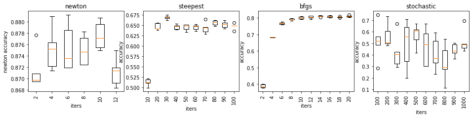

```python
%matplotlib inline
f, ax = plt.subplots(figsize=(16, 3))
plt.subplot(1,4,1)
plt.boxplot(newton_accs)
plt.xticks(range(1,len(newton_iters)+1),[ i for i in newton_iters],rotation='vertical')
plt.xlabel('iters')
#plt.ylim(0.5,0.9)
plt.ylabel('newton accuracy')
plt.title("newton")

plt.subplot(1,4,2)
plt.boxplot(steepest_accs)
plt.xticks(range(1,len(steepest_iters)+1),[i for i in steepest_iters],rotation='vertical')
plt.xlabel('iters')
#plt.ylim(0.35,0.9)
plt.ylabel('accuracy')
plt.title("steepest")

plt.subplot(1,4,3)
plt.boxplot(bfgs_accs)
plt.xticks(range(1,len(bfgs_iters)+1),[ i for i in bfgs_iters],rotation='vertical')
plt.xlabel('iters')
#plt.ylim(0.35,0.9)
plt.ylabel('accuracy')
plt.title("bfgs")


plt.subplot(1,4,4)
plt.boxplot(stochastic_accs)
plt.xticks(range(1,len(stochastic_iters)+1),[i for i in stochastic_iters],rotation='vertical')
plt.xlabel('iters')
#plt.ylim(0.2,0.9)
plt.ylabel('accuracy')
plt.title("stochastic")
plt.show()
```

```python
# to use the cross validation object in scikit learn, we need to grab an instance
#    of the object and set it up. This object will be able to split our data into
#    training and testing splits


def lr_explor(cost,sol,i):
    lr_clf = MultiClassLogisticRegression(eta=1,
                                  iterations=i,
                                  C=float(cost),
                                  regulation="L2",
                                  l1_ratio=0.1,
                                  solver=sol
                                 )

    lr_clf.fit(X_train,y_train)  # train object
    y_test_hat = lr_clf.predict(X_test) # get test set predictions
    test_acc=mt.accuracy_score(list(y_test),list(y_test_hat))
    return test_acc

costs = np.logspace(-5,1,10)
test_accs=np.zeros((4,10))
for j in range(10):
    test_accs[0,j]=(lr_explor(costs[j],"steepest-descent",30))
    test_accs[1,j]=(lr_explor(costs[j],"newton-cg",10))
    test_accs[2,j]=(lr_explor(costs[j], "bfgs",10))
    test_accs[3,j]=(lr_explor(costs[j],"stochastic-gradient-descent",500))
```

[output not shown]

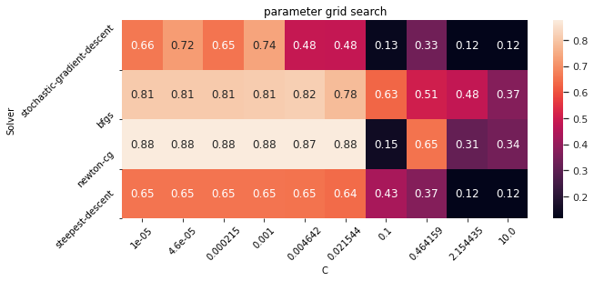

```python
solvers=["steepest-descent", "newton-cg", "bfgs","stochastic-gradient-descent"]
fig,ax=plt.subplots(figsize=(10,4))
cmap = sns.set(style="darkgrid")
sns.heatmap(test_accs,cmap=cmap,annot=True)
plt.gca().invert_yaxis()
plt.ylabel("Solver")
plt.xlabel("C")
plt.title("parameter grid search")
plt.xticks([i+0.5 for i in range(10)], [round(i,6) for i in costs],rotation = 45)
plt.yticks([i for i in range(4)], solvers,rotation = 45)
```

**From the parameter grid search plot, we can see, the best parameter is C = 0.0215 when using newton-cg optimization**

**We think there are some "data snooping" involved with this method of selecting parameters.**

**Frist, we should split data into train set, validation set and test set, and do the parameter search using validation set. Because when do the parameter search on test set, the model also learns from the test set data. In this case, when we predict a new data set which has not been learn by the model, the accuracy may not be as high as that of test set.**

**Second, scaling the data set before spliting into train-test set will also include data snooping problem, because the scaled data shares the same mean, maximum and minimum values. The training data should be scaled independently of the test data"**

### 2.3 Compare the performance of your "best" logistic regression optimization procedure to the procedure used in scikit-learn.

Visualize the performance differences in terms of training time and classification performance. Discuss the results.

```python
%%time

lr_sk = LogisticRegression(solver='newton-cg',n_jobs=1,
                           multi_class='ovr', C = 1/0.0215,
                           penalty='l2',
                          max_iter=30) # all params default
# note that sklearn is optimized for using the liblinear library with logistic regression
# ...and its faster than our implementation here

lr_sk.fit(X_train, list(y_train)) # no need to add bias term, sklearn does it internally!!
yhat = lr_sk.predict(X_test)
print('Accuracy of: ',accuracy_score(list(y_test),yhat))
```

```
Accuracy of:  0.874931129476584
CPU times: user 11.7 s, sys: 8.86 s, total: 20.5 s
Wall time: 576 ms
```

```python
%%time

lr_clf = MultiClassLogisticRegression(eta=1,
                                  iterations=10,
                                  C=0.0215,
                                  regulation="L2",
                                  l1_ratio=0.1,
                                  solver="newton-cg"
                                 )

lr_clf.fit(X_train,y_train)  # train object
y_test_hat = lr_clf.predict(X_test) # get test set predictions
print('Accuracy of: ',mt.accuracy_score(list(y_test),list(y_test_hat)))
```

```
Accuracy of:  0.8752066115702479
CPU times: user 3min 57s, sys: 1min 44s, total: 5min 41s
Wall time: 19.5 s
```

|  | custom | sklearn |
| --- | --- | --- |
| accuracy | 0.8752 | 0.8749 |
| wall time | 19.5s | 576ms |

**According to the accuracy, customed optimization procedure and sklearn optimization procedure has the same performance. However sklearn procedure is way faster than the optimization procedure.**

## 3. Deployment

**We want to deploy this model to the game or a web server. As this game updates annually, it doesn't require frequent trainings, so we can just provide our pre-trained model. In this circumstance, accuracy is more important than the training time.**

## 4. Exceptional Work

For logistic regression, we can calculate the formula for the $j^{th}$ and $k^{th}$ element of the Hessian as follows:

$$ \mathbf{H}_{j,k}(\mathbf{w}) = \frac{\partial}{\partial w_k} \underbrace{\frac{\partial}{\partial w_j}J(\mathbf{w})}_{\text{first derivative}} $$$$ J(\mathbf{w}) = \sum_i (y^{(i)}-g(\mathbf{w}^T\cdot\mathbf{x}^{(i)}))^{2} $$

the result of the $j^{th}$ partial derivative $\nabla J(\mathbf{w})$:

$$ \frac{\partial}{\partial w_j}J(\mathbf{w}) = \sum_i \left (-2 *[y^{(i)}*g(\mathbf{w}^T\cdot\mathbf{x}^{(i)})-g(\mathbf{w}^T\cdot\mathbf{x}^{(i)})^{2}-y^{(i)}*g(\mathbf{w}^T\cdot\mathbf{x}^{(i)})^{2}+g(\mathbf{w}^T\cdot\mathbf{x}^{(i)})^{3}]\right)x_j^{(i)} $$

So we can plug this back into the equation to get:

$$ \begin{split} \mathbf{H}_{j,k}(\mathbf{w}) & = \frac{\partial}{\partial w_k} \sum_i \left(-2 *[y^{(i)}*g(\mathbf{w}^T\cdot\mathbf{x}^{(i)})-g(\mathbf{w}^T\cdot\mathbf{x}^{(i)})^{2}-y^{(i)}*g(\mathbf{w}^T\cdot\mathbf{x}^{(i)})^{2}+g(\mathbf{w}^T\cdot\mathbf{x}^{(i)})^{3}]\right)x_j^{(i)}\\ & = \sum_{i=1}^M \left[-2 *[y^{(i)}-2*g(\mathbf{w}^T\cdot\mathbf{x}^{(i)})-2*y^{(i)}*g(\mathbf{w}^T\cdot\mathbf{x}^{(i)})+3*g(\mathbf{w}^T\cdot\mathbf{x}^{(i)})^{2}]*g(\mathbf{w}^T\cdot\mathbf{x}^{(i)})(1-g(\mathbf{w}^T\cdot\mathbf{x}^{(i)}))\right]\cdot{x_k}^{(i)}{x_j}^{(i)} \\ \end{split} $$

**So the get_gradient function can be update as follows:**

```python
class MultiClassLogisticRegression:
    def __init__(self, eta, iterations=20,  C=0.0001, solver="newton-cg", regulation="L2",l1_ratio=0.1):
        if regulation not in "L1,L2, elasticnet, None":
            print("regulation not recognized. Defaulting to L2.")
            regulation="L2"
        self.eta = eta
        self.iters = iterations
        self.C = C
        self.solver = solver
        self.regu = regulation
        self.l1_ratio=l1_ratio
        self.classifiers_ = []
        # internally we will store the weights as self.w_ to keep with sklearn conventions
        # convenience, private:

    @staticmethod
    def _add_bias(X):
        return np.hstack((np.ones((X.shape[0],1)),X)) # add bias term

    @staticmethod
    def _sigmoid(theta):
        # increase stability, redefine sigmoid operation
        return expit(theta) #1/(1+np.exp(-theta))

    @staticmethod
    def _L1(gradient,w,C):
        for i in range(1,w.shape[0]):
            if w[i] !=0:
                gradient[i] += -1 * C * (w[i])/np.abs(w[i])
            else:
                gradient[i] += 0
        return gradient

    @staticmethod
    def _L2(gradient,w,C):
        gradient[1:] += -2 * w[1:] * C
        return gradient

    @staticmethod
    def _elasticnet(gradient,w,C,l1_ratio):
        for i in range(1,w.shape[0]):
            if w[i] !=0:
                gradient[i] += -2 * w[i] * C * (1-l1_ratio) -1 * C * (w[i])/np.abs(w[i])
            else:
                gradient[i] += -2 * w[i] * C * (1-l1_ratio)
        return gradient



    @staticmethod
    def objective_function(w,X,y,C,l1_ratio,regulation):
        g = expit(X @ w)
        # invert this because scipy minimizes, but we derived all formulas for maximzing
        return -np.sum(ma.log(g[y==1]))-np.sum(ma.log(1-g[y==0])) + C*sum(w**2)
        #-np.sum(y*np.log(g)+(1-y)*np.log(1-g))

    @staticmethod
    def objective_gradient(w,X,y,C,l1_ratio,regulation):
        g = expit(X @ w)
        ydiff = y-g # get y difference
        gradient = np.mean(X * ydiff[:,np.newaxis], axis=0)
        gradient = gradient.reshape(w.shape)
        if regulation == "L2":
            gradient[1:] += -2 * w[1:] * C
        elif regulation == "L1":
            gradient[1:] += -1 * C
        elif regulation == "elasticnet":
            gradient[1:] += -2 * w[1:] * C * (1-l1_ratio) -1 * C * l1_ratio
        elif regulation == None:
            gradient=gradient
        return -gradient

    @staticmethod
    def options():
        print("regulation: L1, L2, elasticnet, None")
        print("solver: stochastic-gradient-descent, steepest-descent, newton-cg, bfgs")

    def _get_gradient_newton(self,X,y):
        g = self._predict_proba(X,add_bias=False).ravel() # get sigmoid value for all classes
        ydiff = y-g # get y difference
        gradient = np.sum(X * ydiff[:,np.newaxis], axis=0) # make ydiff a column vector and multiply through
        gradient = gradient.reshape(self.w_.shape)
        if self.regu == "L2":
            hessian = X.T @ np.diag(g*(1-g)) @ X - 2 * self.C # calculate the hessian
            gradient=self._L2(gradient,self.w_,self.C)
        elif self.regu == "L1":
            hessian = X.T @ np.diag(g*(1-g)) @ X  # calculate the hessian
            gradient=self._L1(gradient,self.w_,self.C)
        elif self.regu == "elasticnet":
            hessian = X.T @ np.diag(g*(1-g)) @ X - 2 * self.C * self.l1_ratio # calculate the hessian
            gradient=self._elasticnet(gradient,self.w_,self.C,self.l1_ratio)
        elif self.regu == None:
            gradient=gradient
        return pinv(hessian) @ gradient
    def _get_gradient_newton_mse(self,X,y):
        g = self._predict_proba(X,add_bias=False).ravel() # get sigmoid value for all classes
        ydiff = y-g # get y difference
        gradient = np.sum(X * ydiff[:,np.newaxis], axis=0) # make ydiff a column vector and multiply through
        gradient = gradient.reshape(self.w_.shape)
        if self.regu == "L2":
            hessian = X.T @ np.diag(2*(3*g*g-2*g*y-2*g+y)*g*(1-g)) @ X - 2 * self.C # calculate the hessian
            gradient=self._L2(gradient,self.w_,self.C)
        elif self.regu == "L1":
            hessian = X.T @ np.diag(2*(3*g*g-2*g*y-2*g+y)*g*(1-g)) @ X  # calculate the hessian
            gradient=self._L1(gradient,self.w_,self.C)
        elif self.regu == "elasticnet":
            hessian = X.T @ np.diag(2*(3*g*g-2*g*y-2*g+y)*g*(1-g)) @ X  - 2 * self.C * self.l1_ratio # calculate the hessian
            gradient=self._elasticnet(gradient,self.w_,self.C,self.l1_ratio)
        elif self.regu == None:
            gradient=gradient
        return pinv(hessian) @ gradient
    def _get_gradient_steepest(self,X,y):
        ydiff = y-self._predict_proba(X,add_bias=False).ravel() # get y difference
        gradient = np.mean(X * ydiff[:,np.newaxis], axis=0) # make ydiff a column vector and multiply through
        gradient = gradient.reshape(self.w_.shape)
        if self.regu == "L2":
            gradient=self._L2(gradient,self.w_,self.C)
        elif self.regu == "L1":
            gradient=self._L1(gradient,self.w_,self.C)
        elif self.regu == "elasticnet":
            gradient=self._elasticnet(gradient,self.w_,self.C,self.l1_ratio)
        elif self.regu == None:
            gradient=gradient
        return gradient

    def _get_gradient_stochastic(self,X,y):
        idx = int(np.random.rand()*len(y)) # grab random instance
        ydiff = y[idx]-self._predict_proba(X[idx],add_bias=False) # get y difference (now scalar)
        gradient = X[idx] * ydiff[:,np.newaxis] # make ydiff a column vector and multiply through
        gradient = gradient.reshape(self.w_.shape)
        if self.regu == "L2":
            gradient=self._L2(gradient,self.w_,self.C)
        elif self.regu == "L1":
            gradient=self._L1(gradient,self.w_,self.C)
        elif self.regu == "elasticnet":
            gradient=self._elasticnet(gradient,self.w_,self.C,self.l1_ratio)
        elif self.regu == None:
            gradient=gradient
        return gradient

    def _get_gradient(self,X,y):
        if self.solver=="stochastic-gradient-descent":
            return self._get_gradient_stochastic(X,y)
        elif self.solver=="steepest-descent":
            return self._get_gradient_steepest(X,y)
        elif self.solver == "newton-cg":
            return self._get_gradient_newton(X,y)
        elif self.solver == "newton-cg-mse":
            return self._get_gradient_newton_mse(X,y)



    def _fit_bfgs(self, X, y):
        Xb = self._add_bias(X) # add bias term
        num_samples, num_features = Xb.shape

        self.w_ = fmin_bfgs(self.objective_function, # what to optimize
                            np.zeros((num_features,1)), # starting point
                            fprime=self.objective_gradient, # gradient function
                            args=(Xb,y,self.C,self.l1_ratio,self.regu), # extra args for gradient and objective function
                            gtol=1e-03, # stopping criteria for gradient, |v_k|
                            maxiter=self.iters, # stopping criteria iterations
                            disp=False)
        self.w_ = self.w_.reshape((num_features,1))


    # public:
    def _predict_proba(self,X,add_bias=True):
        # add bias term if requested
        Xb = self._add_bias(X) if add_bias else X
        return self._sigmoid(Xb @ self.w_) # return the probability y=1

    def _predict(self,X):
        return (self._predict_proba(X)>0.5) #return the actual prediction


    def _fit(self, X, y):
        Xb = self._add_bias(X) # add bias term
        num_samples, num_features = Xb.shape

        self.w_ = np.zeros((num_features,1)) # init weight vector to zeros

        # for as many as the max iterations
        for _ in range(self.iters):
            gradient = self._get_gradient(Xb,y)
            self.w_ += gradient*self.eta # multiply by learning rate
            # add bacause maximizing

    def fit(self,X,y):
        num_samples, num_features = X.shape
        self.unique_ = np.sort(np.unique(y)) # get each unique class value
        num_unique_classes = len(self.unique_)
        self.classifiers_ = []
        for i,yval in enumerate(self.unique_): # for each unique value
            y_binary = np.array(y==yval).astype(int) # create a binary problem
            # train the binary classifier for this class
            hblr = MultiClassLogisticRegression(eta=self.eta,iterations=self.iters,C=self.C,l1_ratio=self.l1_ratio,regulation=self.regu,solver=self.solver)
            fit_function=hblr._fit_bfgs if hblr.solver =="bfgs" else hblr._fit
            fit_function(X,y_binary)
            # add the trained classifier to the list
            self.classifiers_.append(hblr)
        # save all the weights into one matrix, separate column for each class
        self.w_ = np.hstack([x.w_ for x in self.classifiers_]).T
    def predict_proba(self,X):
        probs = []
        for hblr in self.classifiers_:
            probs.append(hblr._predict_proba(X).reshape((len(X),1))) # get probability for each classifier

        return np.hstack(probs) # make into single matrix

    def predict(self,X):
        return np.argmax(self.predict_proba(X),axis=1) # take argmax along row
```

```python
%%time
mse_accs=[]
for i in range(1,11):
    lr =  MultiClassLogisticRegression(eta=1,
                                      iterations=i,
                                      C=0.0215,
                                      regulation="L2",
                                      l1_ratio=0.1,
                                      solver="newton-cg-mse"
                                     )
    lr.fit(X_train,y_train)
    yhat = lr.predict(X_test)
    mse_accs.append(accuracy_score(list(y_test),list(yhat)))
    print(f"iterations: {i}, accuracy {accuracy_score(list(y_test),list(yhat))}")
```

```
iterations: 1, accuracy 0.0013774104683195593
iterations: 2, accuracy 0.8721763085399449
iterations: 3, accuracy 0.19614325068870522
iterations: 4, accuracy 0.7239669421487603
iterations: 5, accuracy 0.721763085399449
iterations: 6, accuracy 0.7212121212121212
iterations: 7, accuracy 0.7192837465564739
iterations: 8, accuracy 0.7173553719008264
iterations: 9, accuracy 0.7168044077134986
iterations: 10, accuracy 0.7146005509641873
CPU times: user 21min 45s, sys: 9min 41s, total: 31min 26s
Wall time: 1min 48s
```

```python
%%time
log_accs=[]
for i in range(1,11):
    lr = MultiClassLogisticRegression(eta=1,
                                      iterations=i,
                                      C=0.0215,
                                      regulation="L2",
                                      l1_ratio=0.1,
                                      solver="newton-cg"
                                     )
    lr.fit(X_train,y_train)
    yhat = lr.predict(X_test)
    log_accs.append(accuracy_score(list(y_test),list(yhat)))
    print(f"iterations: {i}, accuracy {accuracy_score(list(y_test),list(yhat))}")
```

```
iterations: 1, accuracy 0.8702479338842976
iterations: 2, accuracy 0.8713498622589532
iterations: 3, accuracy 0.8724517906336088
iterations: 4, accuracy 0.8730027548209366
iterations: 5, accuracy 0.874931129476584
iterations: 6, accuracy 0.874931129476584
iterations: 7, accuracy 0.8746556473829201
iterations: 8, accuracy 0.8752066115702479
iterations: 9, accuracy 0.8752066115702479
iterations: 10, accuracy 0.8752066115702479
CPU times: user 21min 52s, sys: 9min 42s, total: 31min 35s
Wall time: 1min 48s
```

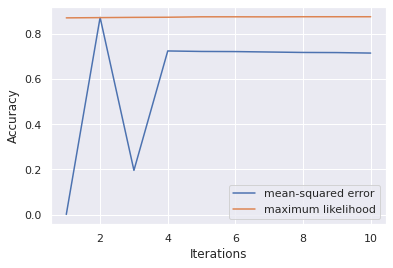

```python
fig, ax = plt.subplots()

ax.plot(range(1,11), mse_accs, label='mean-squared error')
ax.plot(range(1,11), log_accs, label='maximum likelihood')

ax.set_ylabel('Accuracy')
ax.set_xlabel('Iterations')
ax.legend()

plt.show()
```

**maximum likelihood is prefered.**

**Because maximum likelihood loss function is convex, it is guranteed to find a global minimum as we can see from the above plot, with iteration increasing, the accuracy is increasing.**

**However, mean-squared error loss function is not convex, it is not guranteed find a global minimum. And in high dimensions, Newton's method can converge to a saddle point instead of to a local minimum, which explains even at second step it finds the minimum(the highest accuracy), however with iteration increasing, it converge to a saddle point.**